# Reproducible Research with R - An example

Richard Upton

Thursday, July 16, 2015

This example illustrates the power of using a scripting language like R for reproducible research, as discussed in this paper by Gentleman and Lang:

Gentleman, 2004

Reproducible research requires the integration of the computations and code used in data analyses, methodological descriptions, simulations, etc. with the documents that describe and rely on them. The analyse method should be completely traceable from the original data file to the final report/manuscript. This means doing the entire analysis using a scripting language rather than a series of untraceable menu selections in a gui. This document is actually written in Markdown, a simple text language that can include “chunks” of R code.

This analysis makes use of several simple collections of functions which are kept in the SourceFiles subfolder:  
* *functions_wfn.R* allows Wings for NONMEM to be run within R

- *functions_study_plot.R* has pre-written plotting functions in ggplot2 developed specifically for this data set. They are an extension of plots used for data check-out.
- *functions_utility.R* is a collection of miscellaneous utility functions that perform common tasks.

In practice, it is better to divide code into functions and/or blocks. This is one long script for illustration.

# ——————————————————————————-

## Using R for data collation

The data were supplied on 31 Jan as three spreadsheets:

concs.csv

doses.csv

covariates.csv

### Set up the R environment

```r
> #remove all current objects in the workspace
>  rm(list=ls(all=TRUE))
>
>
> #Set the working directory
>   working.dir <- "P:/OSUcourse2015/Rcourse_Day1/0_Rdemo"
>   setwd(working.dir)
>
> #Load libraries
>   library(ggplot2)
>   library(GGally)
>   library(doBy)
>   library(reshape)
>   library(grid)
>   library(cowplot)
>
> #Source WfN functions
>   source("SourceFiles/functions_WfN.R")
>
> #Source study specific plot functions
>   source("SourceFiles/functions_study_plot.R")
>
> #Source utility functions
>   source("SourceFiles/functions_utility.R")
```

### Read the file of concentration data

```r
>   concdatain <- read.csv("concs.csv")
>
>   head(concdatain)
```

```
  TIME  ID1  ID2  ID3  ID4  ID5  ID6  ID7  ID8  ID9 ID10 ID11 ID12 ID13
1  2.5 0.42 0.23 0.29 3.76 0.96 0.02 0.01 0.03 0.06 0.02 1.32 4.25 2.83
2  5.0 0.40 0.49 0.26 1.92 0.68 0.06 0.02 0.12 0.16 0.04 1.66 3.77 3.06
3 10.0 0.32 0.35 0.38 0.54 0.43 0.15 0.08 0.16 0.22 0.10 1.42 2.24 1.70
4 15.0 0.36 0.19 0.19 0.72 0.24 0.13 0.08 0.15 0.47 0.12 1.10 1.48 1.07
5 30.0 0.09 0.17 0.14 0.35 0.24 0.16 0.08 0.18 0.19 0.19 0.58 1.13 0.58
6 60.0 0.07 0.12 0.09 0.22 0.19 0.16 0.07 0.13 0.15 0.16 0.38 0.54 0.38
  ID14 ID15 ID16 ID17 ID18 ID19 ID20
1 4.59 1.50 0.13 0.06 0.05 0.05 0.05
2 3.53 1.36 0.28 0.11 0.09 0.12 0.12
3 1.96 1.06 0.52 0.24 0.24 0.24 0.27
4 0.93 0.89 0.50 0.41 0.54 0.23 0.22
5 0.59 0.44 0.56 0.36 0.36 0.36 0.20
6 0.63 0.28 0.48 0.29 0.28 0.35 0.27
```

```r
>   dim(concdatain)
```

```
[1] 14 21
```

### Use the reshape package to convert from a wide to a long format

Manipulating data formats is a very common task in data analysis.

```r
>    concdata_melt <- melt(concdatain, id=c("TIME"), na.rm=T)
>
>    head(concdata_melt)
```

```
  TIME variable value
1  2.5      ID1  0.42
2  5.0      ID1  0.40
3 10.0      ID1  0.32
4 15.0      ID1  0.36
5 30.0      ID1  0.09
6 60.0      ID1  0.07
```

```r
>    dim(concdata_melt)
```

```
[1] 280   3
```

```r
>    concdata <- cast(concdata_melt, variable + TIME ~ ...)
>    #formula is column ~ row, ... is any other variable
>
>    head(concdata)
```

```
  variable TIME (all)
1      ID1  2.5  0.42
2      ID1  5.0  0.40
3      ID1 10.0  0.32
4      ID1 15.0  0.36
5      ID1 30.0  0.09
6      ID1 60.0  0.07
```

```r
>    dim(concdata)
```

```
[1] 280   3
```

### Neaten up

```r
> names(concdata) <- c("ID","TIME","DV")   #rename columns
> concdata$ID <- gsub("ID","",concdata$ID)  #remove unwanted text in ID column
> concdata$ID <- as.numeric(concdata$ID)   #change text to numbers
```

### Read a file of dose data

```r
> dosedata <- read.csv("doses.csv")
> head(dosedata)
```

```
  ID TIME AMT CMT MDV
1  1 -0.1  50   2   1
2  2 -0.1  50   2   1
3  3 -0.1  50   2   1
4  4 -0.1  50   2   1
5  5 -0.1  50   2   1
6  6 -0.1  50   1   1
```

```r
> dim(dosedata)
```

```
[1] 20  5
```

### Read a file of covariate data

```r
> covdata <- read.csv("covariates.csv")
> head(covdata)
```

```
  ID       Description GROUP DOSE ROUTE AGE AGE2 WEIGHT
1  1 Fentanyl 50 ug iv     1   50     0  32    0     75
2  2 Fentanyl 50 ug iv     1   50     0  79    1     54
3  3 Fentanyl 50 ug iv     1   50     0  60    1     90
4  4 Fentanyl 50 ug iv     1   50     0  79    1     63
5  5 Fentanyl 50 ug iv     1   50     0  25    0     66
6  6 Fentanyl 50 ug sc     2   50     1  64    1     68
```

```r
> dim(covdata)
```

```
[1] 20  8
```

### Merge data from the 3 files into 1 dataframe

```r
> alldata <- merge(concdata,dosedata, all=T)
> alldata <- merge(alldata,covdata, all=T)
```

### Tidy up merged data to suit NONMEM’s requirements

```r
> alldata$CMT[is.na(alldata$CMT)==T] <- 2   #Assign remaining compartment flags
> alldata$MDV[is.na(alldata$MDV)==T] <- 0   #Assign remaining missing data flags
> alldata$TIME[alldata$TIME==-0.1] <- 0     #Adjust time for dose events
>
> alldata <- subset(alldata, select=c(-Description))  #Remove description column
> names(alldata)[1] <- "CID"                          #Comment out column labels
```

### Inspect and write in NONMEM format

```r
>     head(alldata)
```

```
  CID TIME   DV AMT CMT MDV GROUP DOSE ROUTE AGE AGE2 WEIGHT
1   1  0.0   NA  50   2   1     1   50     0  32    0     75
2   1  2.5 0.42  NA   2   0     1   50     0  32    0     75
3   1  5.0 0.40  NA   2   0     1   50     0  32    0     75
4   1 10.0 0.32  NA   2   0     1   50     0  32    0     75
5   1 15.0 0.36  NA   2   0     1   50     0  32    0     75
6   1 30.0 0.09  NA   2   0     1   50     0  32    0     75
```

```r
>     dim(alldata)
```

```
[1] 300  12
```

```r
>     write.csv(alldata, file="data_example.csv", na=".", quote=F, row.names=F)
```

This produced the following spreadsheet of data in NONMEM format ready for fitting:

data_example.csv

# ——————————————————————————-

## Using R for running a NONMEM model via WfN

A NONMEM control stream was prepared manually, and uses the data file prepared above:

2comp_example.ctl

### Run the control stream

```r
>    nmgo("2comp_example.ctl", pause.nm=F)
```

```
[1] TRUE
```

### Change to the output directory, and run the diagnostic plot functions

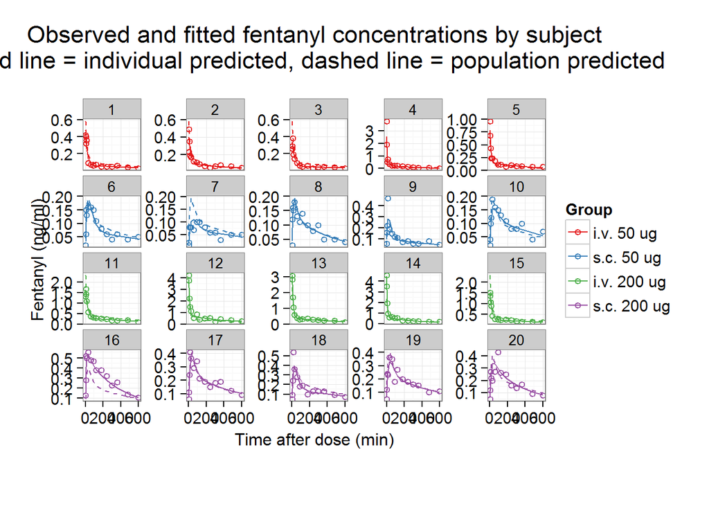

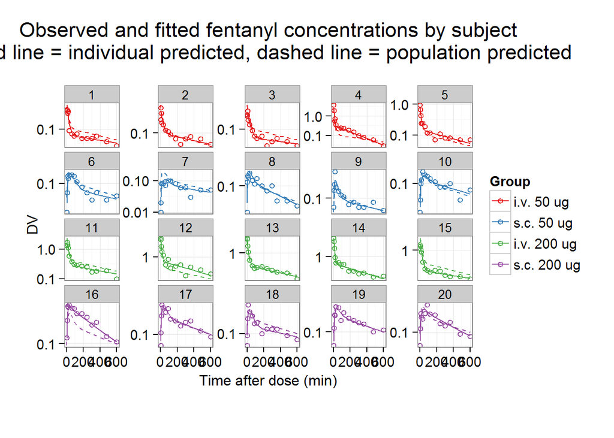

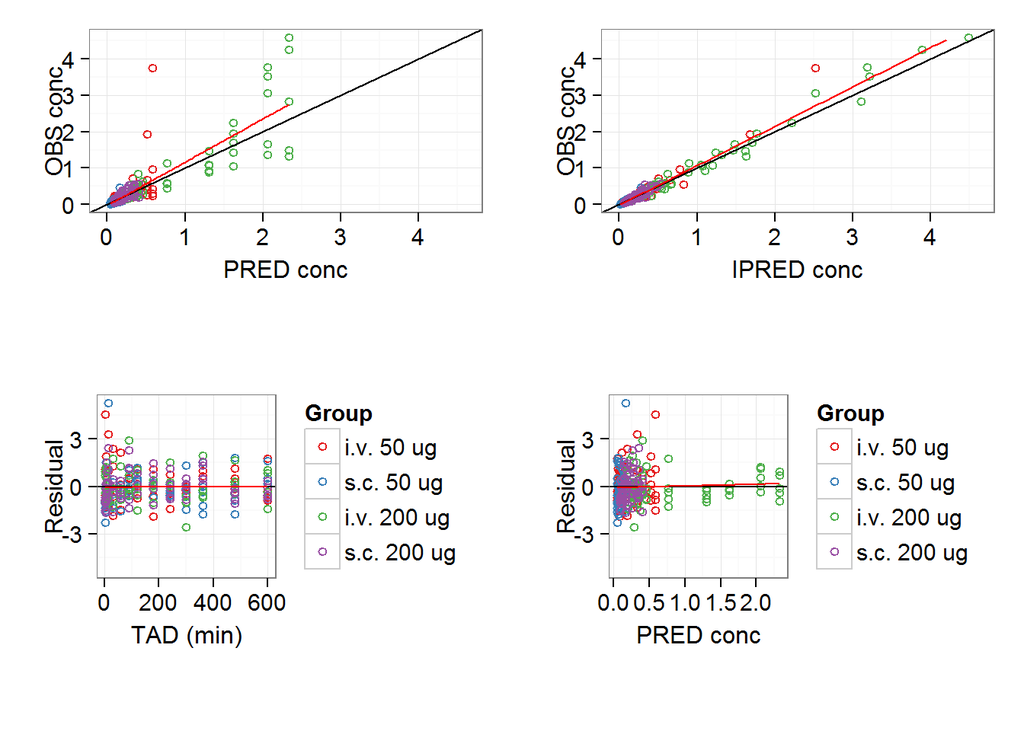

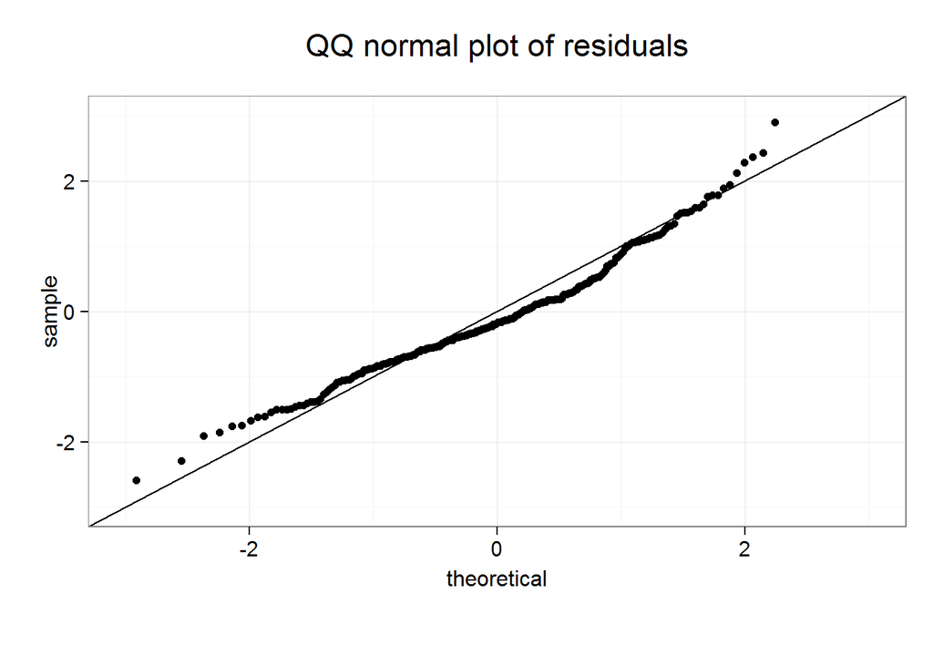

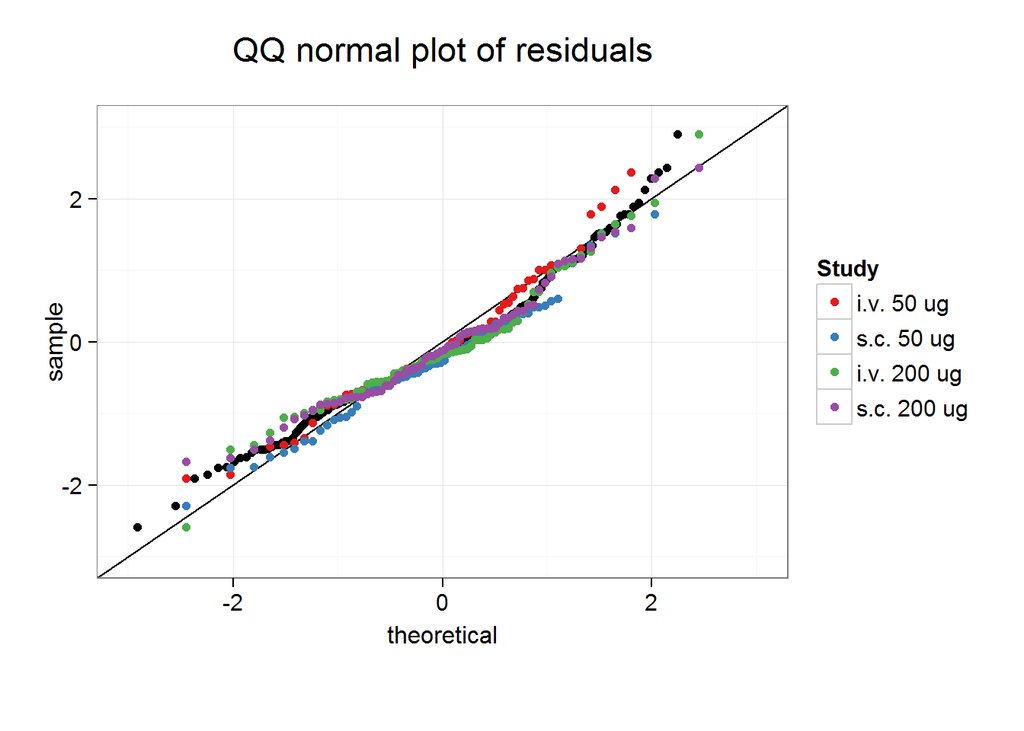

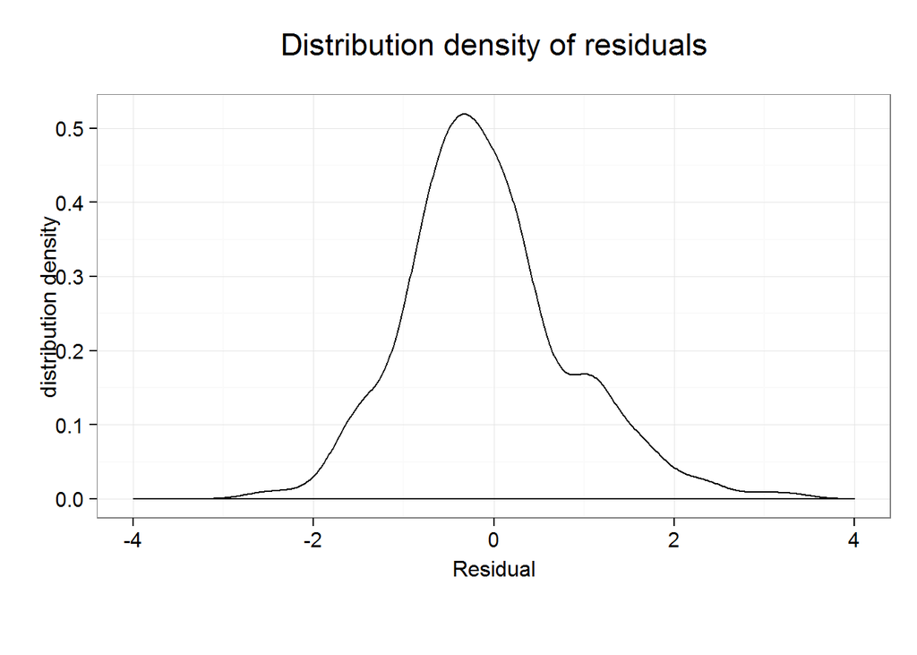

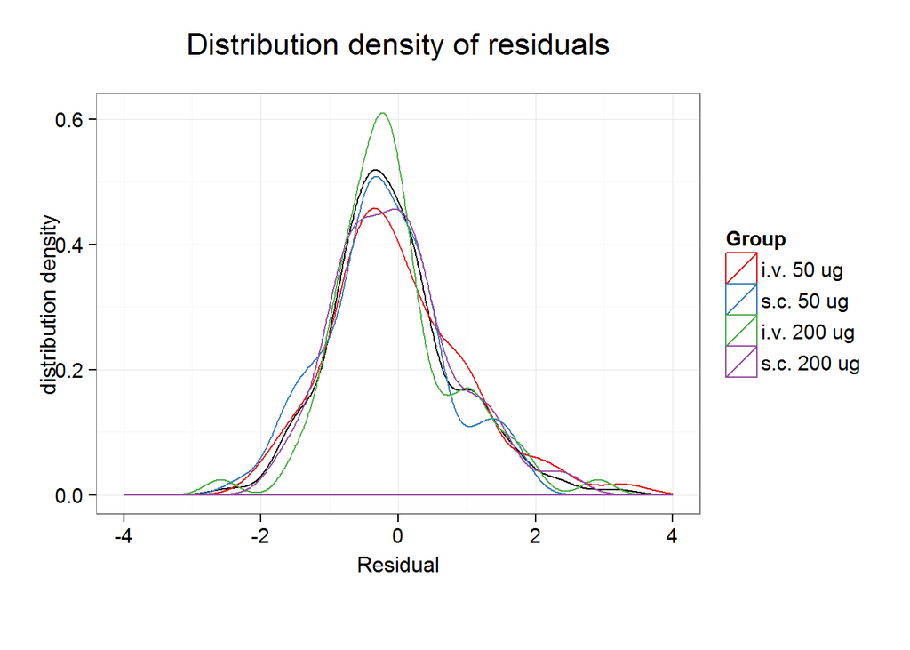

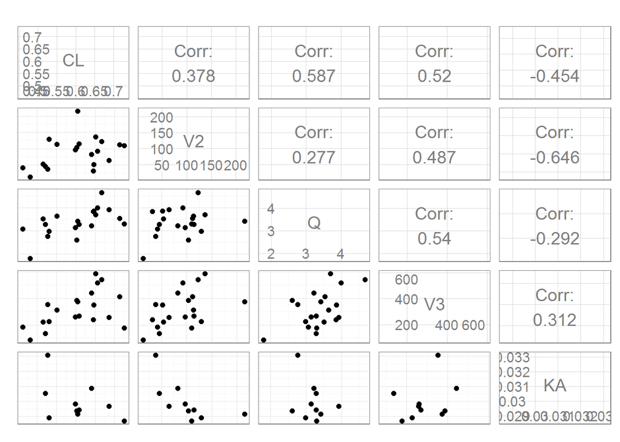

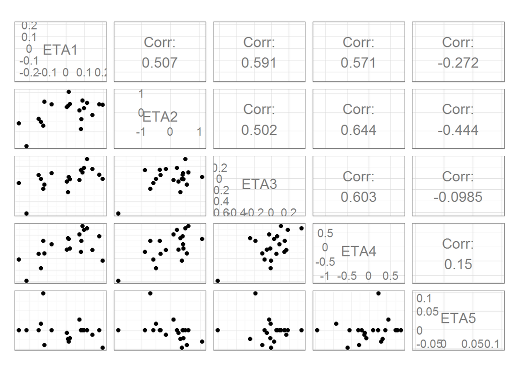

```r
>    output.dir <- "/2comp_example.nm7"
>    setwd(paste(working.dir,output.dir, sep=""))
>
>
>   diagnostic.plots("2comp_example.fit","CWRESI", c("CL","V2","Q","V3","KA"))
```

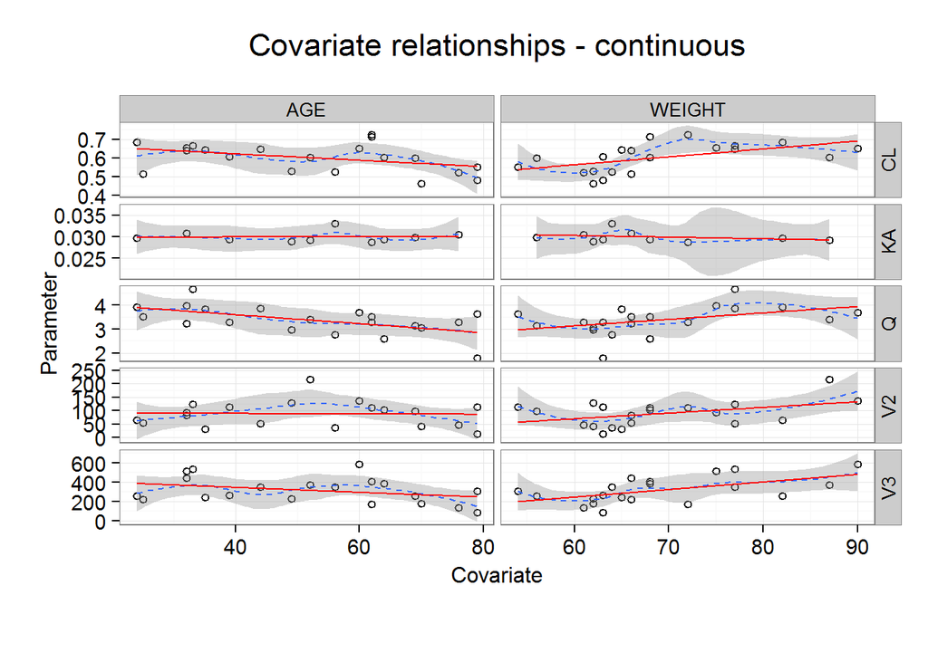

```r
>   covariate.cont.plots("2comp_example.fit", "cov.cont.plot", c("CL","V2","Q","V3","KA"), c("AGE","WEIGHT"))
```

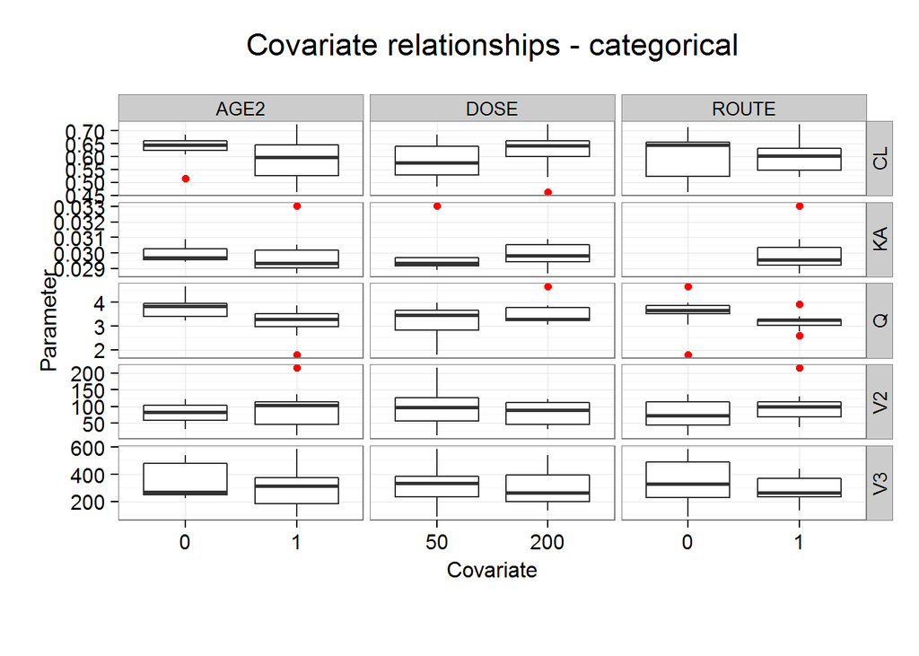

```r
>    covariate.cat.plots("2comp_example.fit", "cov.cat.plot", c("CL","V2","Q","V3","KA"), c("ROUTE","DOSE","AGE2"))
```

```r
>    setwd(working.dir)
```

### Look at the parameter values

```r
>    nmmbt()
```

```
[1] TRUE
```

```r
>    param.table <- read.delim("nmmbt.nm7.txt")
>    param.table
```

```
                Run       Obj Meth Prob        Min  Cov Eval Sig Sub Obs
1     2comp_example -1372.672 FOCE    1 TERMINATED   OK  294 3.8  20 280
2 2comp_example_sim         .   FO    1   ABNORMAL NONE    0 0.0  20 280
    Ttot   Test   Tcov   Ttcl CLPOP V2POP QPOP V3POP KAPOP F200SC   CLPPV
1 0.2072 0.1202 0.0195 0.0675 0.596  75.5 3.33   286  0.03  0.519 0.18303
2 0.0000 0.0000 0.0000 0.0000     .     .    .     .     .      .       .
    V2PPV     QPPV    V3PPV    KAPPV ERRCV CLPOP.se V2POP.se QPOP.se
1 0.66106 0.262679 0.490918 0.141067  0.22     10.6     35.6    15.5
2       .        .        .        .     .        .        .       .
  V3POP.se KAPOP.se F200SC.se CLPPV.se V2PPV.se QPPV.se V3PPV.se KAPPV.se
1     26.5     45.7      18.6    145.1     71.6   112.3     87.1   1055.3
2        .        .         .        .        .       .        .        .
  ERRCV.se  X
1     15.5 NA
2        . NA
```

# —————————————————————————————

## A Visual Predictive Check

### Copy fitted parameter values to control stream and run

```r
>    nmctl("2comp_example.ctl")
```

```
[1] TRUE
```

```r
>    ctl.to.sim("2comp_example.ctl")  #Turns off $EST line, turns on $SIM, appends "_sim." to file name
>    nmgo("2comp_example_sim.ctl", pause.nm=F)
```

```
[1] TRUE
```

### Copy the data file to where it is needed

```r
>    #output.dir <- "/2comp_example_sim.nm7"
>    #setwd(paste(working.dir,output.dir,sep=""))
>
>
>           file.copy(from=paste(working.dir,"/data_example.csv", sep=""),
+                      to=paste(working.dir,"/2comp_example_sim.nm7/data_example.csv",sep=""), overwrite=T)
```

```
[1] TRUE
```

### Read and process the simulated data (*.fit)

```r
>          output.dir <- "/2comp_example_sim.nm7"
>          setwd(paste(working.dir,output.dir,sep=""))
>          read.sim.fit("2comp_example_sim.fit")  #This function avoids the slow read (hours) of the usual scan function
```

```
[1] TRUE
```

### Plot a VPC by DOSE and ROUTE

```r
>    #plot.VPCconc.byDOSEROUTE("data_example.csv","2comp_example_sim.fit.csv")
```

### Example Visual Predictive Check Plot

```r
>   setwd(working.dir)
```

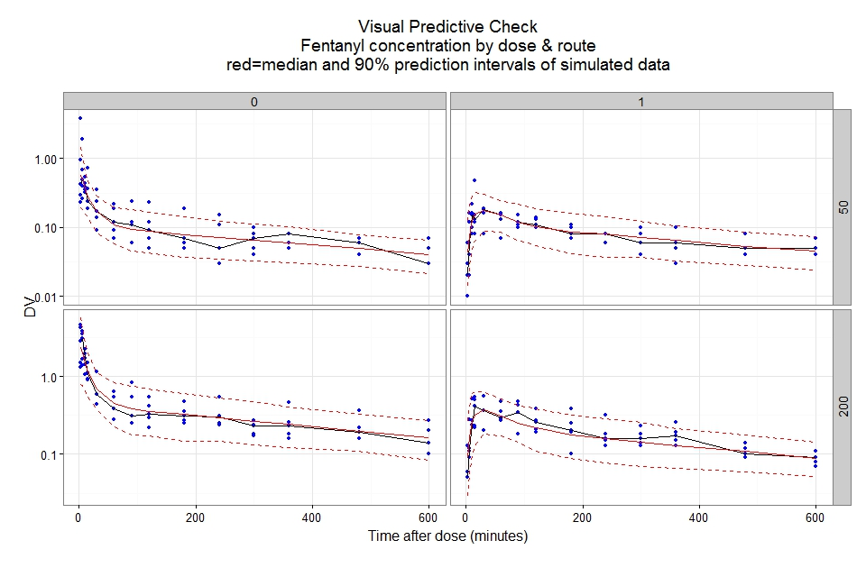